# Indendent Project - Week 1 Module 3

Kelvin Kilel

1/22/2022

# Specifying the Question

A Kenyan entrepreneur has created an online cryptography course and would want to advertise it on her blog. She currently targets audiences originating from various countries. In the past, she ran ads to advertise a related course on the same blog and collected data in the process. She would now like to employ your services as a Data Science Consultant to help her identify which individuals are most likely to click on her ads.

# Defining the Metric of Success

To analyze the different variables and recommend which individuals are most likely to click on ads.

# Understanding the Context

The ability to monitor ads of an organization helps the organization understand the effectiveness of the ads and foster efficiency. Adjustments can be made to create effective ads and ensure the ads get to the target audience.

# Recording the Experimental Design

1. Find and deal with outliers, anomalies, and missing data within the dataset.
2. Perform univariate and bivariate analysis.
3. From your insights provide a conclusion and recommendation.

# Reading the Data

```r
## Loading our dataset
library(data.table)
ad_dataset <- fread('http://bit.ly/IPAdvertisingData')
```

# Checking the Data

```r
## Viewing the dataset
View(ad_dataset)

## Previewing the top of our dataset
head(ad_dataset)
```

```
##    Daily Time Spent on Site   Age Area Income Daily Internet Usage
##                       <num> <int>       <num>                <num>
## 1:                    68.95    35    61833.90               256.09
## 2:                    80.23    31    68441.85               193.77
## 3:                    69.47    26    59785.94               236.50
## 4:                    74.15    29    54806.18               245.89
## 5:                    68.37    35    73889.99               225.58
## 6:                    59.99    23    59761.56               226.74
##                            Ad Topic Line           City  Male    Country
##                                   <char>         <char> <int>     <char>
## 1:    Cloned 5thgeneration orchestration    Wrightburgh     0    Tunisia
## 2:    Monitored national standardization      West Jodi     1      Nauru
## 3:      Organic bottom-line service-desk       Davidton     0 San Marino
## 4: Triple-buffered reciprocal time-frame West Terrifurt     1      Italy
## 5:         Robust logistical utilization   South Manuel     0    Iceland
## 6:       Sharable client-driven software      Jamieberg     1     Norway
##              Timestamp Clicked on Ad
##                 <POSc>         <int>
## 1: 2016-03-27 00:53:11             0
## 2: 2016-04-04 01:39:02             0
## 3: 2016-03-13 20:35:42             0
## 4: 2016-01-10 02:31:19             0
## 5: 2016-06-03 03:36:18             0
## 6: 2016-05-19 14:30:17             0
```

```r
## Previewing the bottom of our dataset
tail(ad_dataset)
```

```
##    Daily Time Spent on Site   Age Area Income Daily Internet Usage
##                       <num> <int>       <num>                <num>
## 1:                    43.70    28    63126.96               173.01
## 2:                    72.97    30    71384.57               208.58
## 3:                    51.30    45    67782.17               134.42
## 4:                    51.63    51    42415.72               120.37
## 5:                    55.55    19    41920.79               187.95
## 6:                    45.01    26    29875.80               178.35
##                           Ad Topic Line          City  Male
##                                  <char>        <char> <int>
## 1:        Front-line bifurcated ability  Nicholasland     0
## 2:        Fundamental modular algorithm     Duffystad     1
## 3:      Grass-roots cohesive monitoring   New Darlene     1
## 4:         Expanded intangible solution South Jessica     1
## 5: Proactive bandwidth-monitored policy   West Steven     0
## 6:      Virtual 5thgeneration emulation   Ronniemouth     0
##                   Country           Timestamp Clicked on Ad
##                    <char>              <POSc>         <int>
## 1:                Mayotte 2016-04-04 03:57:48             1
## 2:                Lebanon 2016-02-11 21:49:00             1
## 3: Bosnia and Herzegovina 2016-04-22 02:07:01             1
## 4:               Mongolia 2016-02-01 17:24:57             1
## 5:              Guatemala 2016-03-24 02:35:54             0
## 6:                 Brazil 2016-06-03 21:43:21             1
```

# Tidying the Dataset

```r
## Checking for Missing Values
colSums(is.na(ad_dataset))
```

```
## Daily Time Spent on Site                      Age              Area Income
##                        0                        0                        0
##     Daily Internet Usage            Ad Topic Line                     City
##                        0                        0                        0
##                     Male                  Country                Timestamp
##                        0                        0                        0
##            Clicked on Ad
##                        0
```

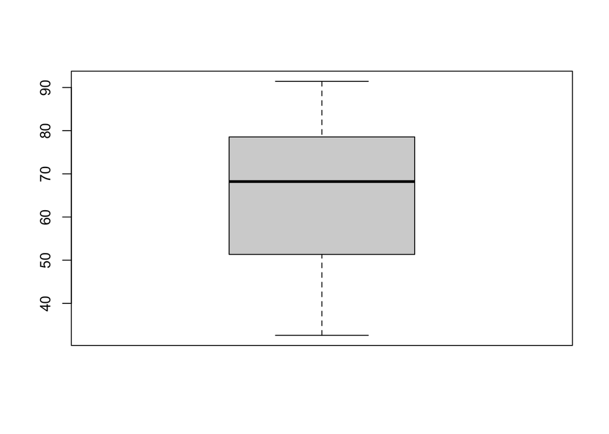

```r
### There are no missing values in our dataset.

## Checking for outliers

boxplot(ad_dataset$'Daily Time Spent on Site')
```

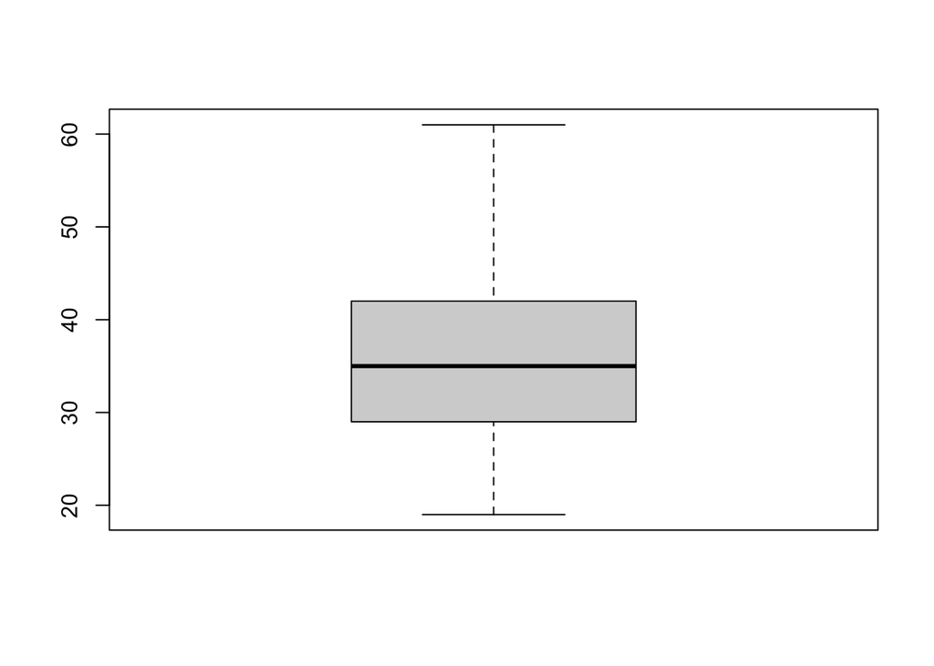

```r
boxplot(ad_dataset$Age)
```

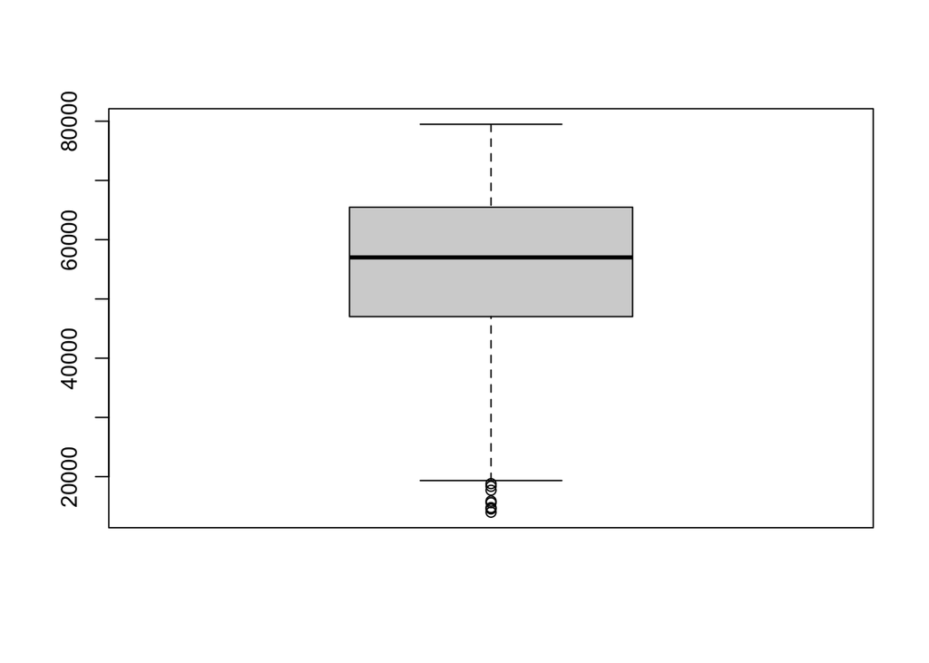

```r
boxplot(ad_dataset$'Area Income')
```

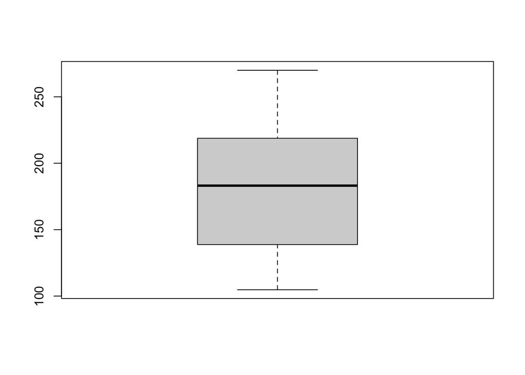

```r
boxplot(ad_dataset$'Daily Internet Usage')
```

```r
### There are outliers on Area Income. This is due to difference in earnings.
```

# Univariate Analysis

```r
### Finding Mean

#### Daily Time Spent on Site
ad_timespent_mean <- mean(ad_dataset$'Daily Time Spent on Site')
ad_timespent_mean
```

```
## [1] 65.0002
```

```r
#### Age

ad_mean_age <- mean(ad_dataset$Age)
ad_mean_age
```

```
## [1] 36.009
```

```r
#### Area Income
ad_mean_income <- mean(ad_dataset$'Area Income')
ad_mean_income
```

```
## [1] 55000
```

```r
#### Daily Internet Usage
ad_mean_internetusage <- mean(ad_dataset$'Daily Internet Usage')
ad_mean_internetusage
```

```
## [1] 180.0001
```

```r
#### Clicked on Ad
ad_mean_clickedad <- mean(ad_dataset$'Clicked on Ad')
ad_mean_clickedad
```

```
## [1] 0.5
```

```r
### Finding Median

#### Daily Time Spent on Site
ad_timespent_median <- median(ad_dataset$'Daily Time Spent on Site')
ad_timespent_median
```

```
## [1] 68.215
```

```r
#### Age

ad_median_age <- median(ad_dataset$Age)
ad_median_age
```

```
## [1] 35
```

```r
#### Area Income
ad_median_income <- median(ad_dataset$'Area Income')
ad_median_income
```

```
## [1] 57012.3
```

```r
#### Daily Internet Usage
ad_median_internetusage <- median(ad_dataset$'Daily Internet Usage')
ad_median_internetusage
```

```
## [1] 183.13
```

```r
### Finding Mode

getmode <- function(v) {
   uniqv <- unique(v)
   uniqv[which.max(tabulate(match(v, uniqv)))]
}

#### Daily Time Spent on Site
ad_timespent_mode <- getmode(ad_dataset$'Daily Time Spent on Site')
ad_timespent_mode
```

```
## [1] 62.26
```

```r
#### Age

ad_mode_age <- getmode(ad_dataset$Age)
ad_mode_age
```

```
## [1] 31
```

```r
#### Area Income
ad_mode_income <- getmode(ad_dataset$'Area Income')
ad_mode_income
```

```
## [1] 61833.9
```

```r
#### Daily Internet Usage
ad_mode_internetusage <- getmode(ad_dataset$'Daily Internet Usage')
ad_mode_internetusage
```

```
## [1] 167.22
```

## Measure of Dispersion

```r
### Finding Minimum

#### Daily Time Spent on Site
ad_timespent_min <- min(ad_dataset$'Daily Time Spent on Site')
ad_timespent_min
```

```
## [1] 32.6
```

```r
#### Age

ad_min_age <- min(ad_dataset$Age)
ad_min_age
```

```
## [1] 19
```

```r
#### Area Income
ad_min_income <- min(ad_dataset$'Area Income')
ad_min_income
```

```
## [1] 13996.5
```

```r
#### Daily Internet Usage
ad_min_internetusage <- min(ad_dataset$'Daily Internet Usage')
ad_min_internetusage
```

```
## [1] 104.78
```

```r
#### Clicked on Ad
ad_min_clickedad <- min(ad_dataset$'Clicked on Ad')
ad_min_clickedad
```

```
## [1] 0
```

```r
### Finding Maximum

#### Daily Time Spent on Site
ad_timespent_max <- max(ad_dataset$'Daily Time Spent on Site')
ad_timespent_max
```

```
## [1] 91.43
```

```r
#### Age

ad_max_age <- max(ad_dataset$Age)
ad_max_age
```

```
## [1] 61
```

```r
#### Area Income
ad_max_income <- max(ad_dataset$'Area Income')
ad_max_income
```

```
## [1] 79484.8
```

```r
#### Daily Internet Usage
ad_max_internetusage <- max(ad_dataset$'Daily Internet Usage')
ad_max_internetusage
```

```
## [1] 269.96
```

```r
### Finding Variance

#### Daily Time Spent on Site
ad_timespent_var <- var(ad_dataset$'Daily Time Spent on Site')
ad_timespent_var
```

```
## [1] 251.3371
```

```r
#### Age

ad_var_age <- var(ad_dataset$Age)
ad_var_age
```

```
## [1] 77.18611
```

```r
#### Area Income
ad_var_income <- var(ad_dataset$'Area Income')
ad_var_income
```

```
## [1] 179952406
```

```r
#### Daily Internet Usage
ad_var_internetusage <- var(ad_dataset$'Daily Internet Usage')
ad_var_internetusage
```

```
## [1] 1927.415
```

```r
### Finding Standard Deviation

#### Daily Time Spent on Site
ad_timespent_sd <- sd(ad_dataset$'Daily Time Spent on Site')
ad_timespent_sd
```

```
## [1] 15.85361
```

```r
#### Age

ad_sd_age <- sd(ad_dataset$Age)
ad_sd_age
```

```
## [1] 8.785562
```

```r
#### Area Income
ad_sd_income <- sd(ad_dataset$'Area Income')
ad_sd_income
```

```
## [1] 13414.63
```

```r
#### Daily Internet Usage
ad_sd_internetusage <- sd(ad_dataset$'Daily Internet Usage')
ad_sd_internetusage
```

```
## [1] 43.90234
```